# DATA 402 HW 5

Author

Sophia Chung

#### Section A: Derivations

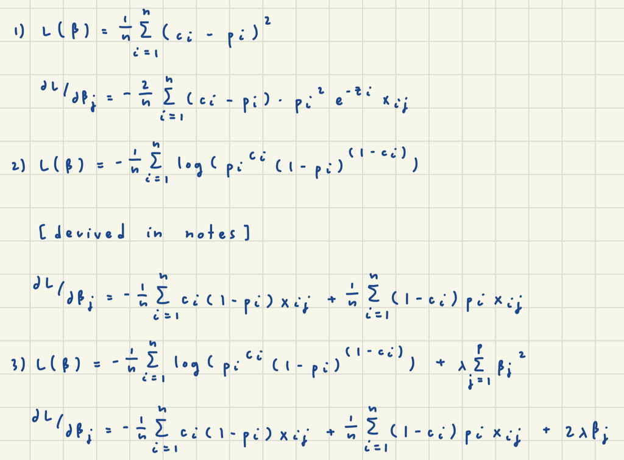

##### 4)

```r
gd_sq_error <- function(x, c, eta) {
  n <- length(x)
  betas <- rep(0, 2)

  # helper functions
  stopping_condition <- function(curr_steps, max_steps=1000, eta, cutoff=1e-9) {
    curr_steps >= max_steps || eta < cutoff
  }

  compute_gradient <- function(x, c, betas) {
    z <- x*betas
    p <- 1/(1 + exp(-z))
    gradient0 <- -2/n * sum((c - p)*p^2*exp(-z))
    gradient1 <- -2/n * sum((c - p)*p^2*exp(-z)*x)
    gradient <- c(gradient0, gradient1)
    return (gradient)
  }

  curr_steps <- 0
  while (!stopping_condition(curr_steps, eta=eta) && curr_steps < 2) {
    cat('Update', curr_steps + 1, '\n')
    gradient <- compute_gradient(x, c, betas)
    cat('Gradient:', gradient, '\n')
    betas <- betas - eta*gradient
    cat('New betas:', betas, '\n')
    curr_steps <- curr_steps + 1
  }
}
```

##### a)

```r
chol <- c(192, 233, 236, 237, 250, 294, 354, 410)
risk <- c(0, 0, 1, 1, 0, 1, 1, 1)
gd_sq_error(chol, risk, eta=0.01)
```

```
Update 1
Gradient: -0.0625 -26.75
New betas: 0.000625 0.2675
Update 2
Gradient: 0.01022342 -1.812092
New betas: 0.0005227658 0.2856209
```

##### b)

```r
gd_sq_error(chol, risk, eta=1)
```

```
Update 1
Gradient: -0.0625 -26.75
New betas: 0.0625 26.75
Update 2
Gradient: 1.576959e-06 0.0003051503
New betas: 0.06249842 26.74969
```

#### Section B: Computer Implementation

##### 1)

```r
gd_logistic <- function(X, Y, eta) {
  n <- nrow(X)
  p <- ncol(X)
  betas <- rep(0, p)

  # helper functions
  stopping_condition <- function(curr_steps, max_steps=1000, eta, cutoff=1e-9) {
    curr_steps >= max_steps || eta < cutoff
  }

  compute_gradient <- function(X, Y, betas) {
    z <- X %*% betas
    p <- 1/(1 + exp(-z))
    gradient <- -1/n * (t(X) %*% (Y*(1 - p))) + 1/n * (t(X) %*% ((1 - Y)*p))
    return (gradient)
  }

  curr_steps <- 0
  while (!stopping_condition(curr_steps, eta=eta)) {
    gradient <- compute_gradient(X, Y, betas)
    betas <- betas - eta*gradient
    curr_steps <- curr_steps + 1
  }
  return (betas)
}
```

```r
ha <- read.csv('heart_attack_clean.csv')
X <- data.matrix(subset(ha, select=-c(output)))
X <- cbind(rep(1, nrow(ha)), X)
Y <- data.matrix(subset(ha, select=c(output)))
B1 <- gd_logistic(X, Y, eta=0.01)
B1
```

```
                output
            0.18298726
age        -0.21610053
trtbps     -0.18801447
chol       -0.12214445
thalach     0.65362331
sex_X0      0.53624873
sex_X1     -0.35326148
cp_X0      -0.60659768
cp_X1       0.27837059
cp_X2       0.42630274
cp_X3       0.08491161
restecg_X0 -0.06266486
restecg_X1  0.26163554
restecg_X2 -0.01598342
```

##### 2)

```r
gd_logistic_ridge <- function(X, Y, lambda, eta) {
  n <- nrow(X)
  p <- ncol(X)
  betas <- rep(0, p)

  # helper functions
  stopping_condition <- function(curr_steps, max_steps=1000, eta, cutoff=1e-9) {
    curr_steps >= max_steps || eta < cutoff
  }

  compute_gradient <- function(X, Y, lambda, betas) {
    z <- X %*% betas
    p <- 1/(1 + exp(-z))
    gradient <- -1/n * (t(X) %*% (Y*(1 - p))) + 1/n * (t(X) %*% ((1 - Y)*p)) + 2*lambda*betas
    return (gradient)
  }

  curr_steps <- 0
  while (!stopping_condition(curr_steps, eta=eta)) {
    gradient <- compute_gradient(X, Y, lambda, betas)
    betas <- betas - eta*gradient
    curr_steps <- curr_steps + 1
  }
  return (betas)
}
```

```r
tune_lambda_cv_ridge <- function(X, Y, metric, lambdas, splits) {
  indices <- sample(1:nrow(X))
  folds <- split(indices, cut(indices, breaks=splits, labels=FALSE))

  avg_metrics <- c()
  for (i in 1:length(lambdas)) {
    metrics <- c()
    for (j in 1:splits) {
      test_indices <- folds[[j]]

      X_test <- X[folds[[j]],]
      y_test <- Y[folds[[j]],]
      X_train <- X[-folds[[j]],]
      y_train <- Y[-folds[[j]],]

      # eta that works for this data set
      betas <- gd_logistic_ridge(X_train, y_train, lambdas[i], 0.001)
      pred <- X_test %*% betas

      if (metric == 'R-squared') {
        r_squared <- 1 - sum((y_test - pred)^2)/sum((y_test - mean(y_test))^2)
        metrics[j] <- r_squared
      }
      else if (metric == 'MSE') {
        metrics[j] <- mean(y_test - pred^2)
      }
      else if (metric == 'MAE') {
        metrics[j] <- mean(abs(y_test - pred))
      }
    }
    avg_metrics[i] <- mean(metrics)
  }

  if (metric == 'R-squared') {
    best_lambda <- lambdas[which.max(avg_metrics)]
  }
  else {
    best_lambda <- lambdas[which.min(avg_metrics)]
  }
  df <- data.frame('lambda'=lambdas, 'metric'=avg_metrics, 'best_lambda'=best_lambda)
  return (df)
}
```

```r
head(tune_lambda_cv_ridge(X, Y, 'MSE', seq(1, 100, 1), 3))
```

```
  lambda    metric best_lambda
1      1 0.5067198           1
2      2 0.5245633           1
3      3 0.5297401           1
4      4 0.5318116           1
5      5 0.5328313           1
6      6 0.5334059           1
```

Using MSE, the best $\lambda$ is 1.

```r
B2 <- gd_logistic_ridge(X, Y, lambda=1, eta=0.001)
B2
```

```
                 output
            0.013976465
age        -0.043557820
trtbps     -0.025190754
chol       -0.014315988
thalach     0.079146754
sex_X0      0.034307473
sex_X1     -0.020331008
cp_X0      -0.044608861
cp_X1       0.020655474
cp_X2       0.033307960
cp_X3       0.004621891
restecg_X0 -0.009754776
restecg_X1  0.025159812
restecg_X2 -0.001428572
```

##### 3)

```r
pred_prob <- function(betas, X) {
  z <- X %*% betas
  p <- 1/(1 + exp(-z))
  return (p)
}
```

```r
head(pred_prob(B1, X))
```

```
     output
1 0.3914195
2 0.8805807
3 0.7837324
4 0.6393349
5 0.3600997
6 0.6904997
```

##### 4)

```r
library(knitr)
plot_roc <- function(X, output, betas1, betas2) {
  # helper function
  get_metrics <- function(X, output, betas) {
    probs <- pred_prob(betas, X)

    tpr <- c()
    fpr <- c()
    for (i in seq(0, 1, by=0.01)) {
      pred <- ifelse(probs >= i, 1, 0)
      cf_matrix <- table(output, pred)
      if (ncol(cf_matrix) == 1) {
        cf_matrix <- cbind('0'=0, cf_matrix)
      }
      tp <- cf_matrix[2, 2]
      tn <- cf_matrix[1, 1]
      fp <- cf_matrix[1, 2]
      fn <- cf_matrix[2, 1]
      tpr[i*100] <- tp/(tp + fn)
      fpr[i*100] <- fp/(fp + tn)
    }
    return (list(fpr, tpr))
  }

  B1_metrics <- get_metrics(X, output, betas1)
  B2_metrics <- get_metrics(X, output, betas2)
  plot(B1_metrics[[1]], B1_metrics[[2]], type='l', col='blue', xlim=c(0, 1), ylim=c(0, 1),
       xlab='False Positive Rate', ylab='True Positive Rate', main='ROC Curve Comparison')
  lines(B2_metrics[[1]], B2_metrics[[2]], type='l', col='orange')
  legend('bottomright', legend=c('B1', 'B2'), col=c('blue', 'orange'), lty=1)
}
```

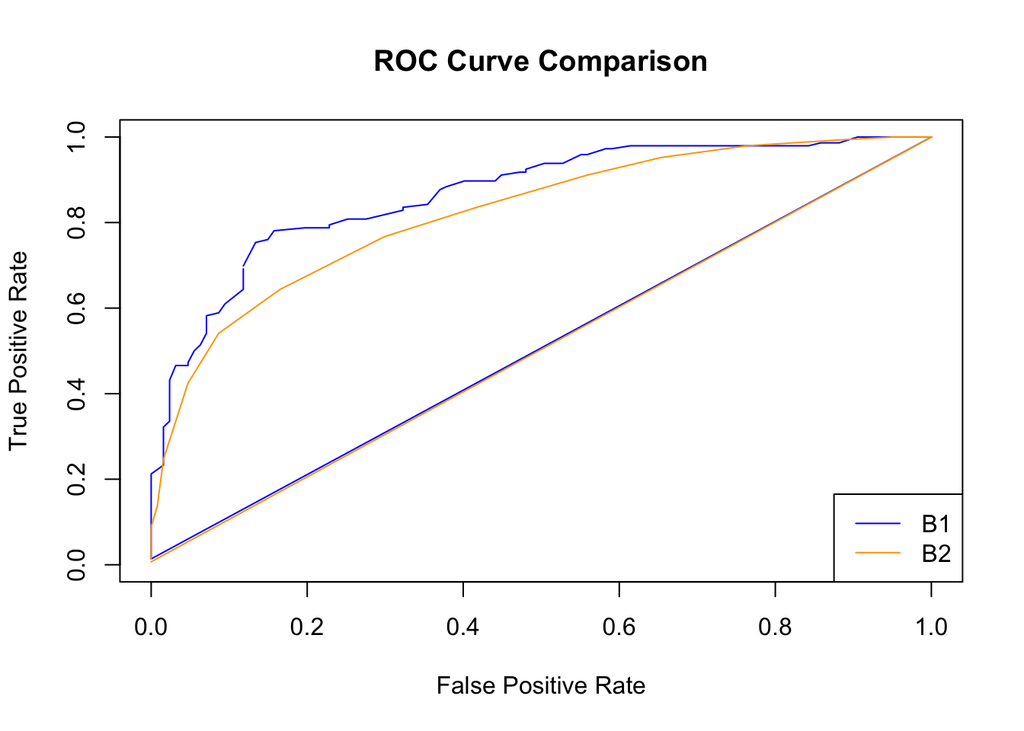

```r
plot_roc(X, ha$output, B1, B2)
```

##### 5)

According to the ROC curve, the model from B1 without the Ridge penalty did better because it has a larger area under the curve.

#### Section C: Concepts

##### 1) Accuracy

```r
(120 + 97)/(120 + 26 + 30 + 97)
```

```
[1] 0.7948718
```

This model makes the correct prediction 79.487% of the time.

##### 2) Precision and Recall

```r
precision <- 120/(120 + 30)
precision
```

```
[1] 0.8
```

Assuming the model predicted that a patient is at risk of a heart attack, it makes the correct prediction 80% of the time.

```r
recall <- 120/(120 + 26)
recall
```

```
[1] 0.8219178
```

The model correctly predicted 82.192% of the patients at risk of a heart attack.

##### 3) Sensitivity and Specificity

```r
120/(120 + 26)
```

```
[1] 0.8219178
```

The model correctly predicted 82.192% of the patients at risk of a heart attack.

```r
97/(97 + 30)
```

```
[1] 0.7637795
```

The model correctly predicted 76.378% of the patients not at risk of a heart attack.

##### 4) F1 Score

```r
1/(0.5*(1/precision + 1/recall))
```

```
[1] 0.8108108
```

The harmonic mean between precision and recall of this model is 0.8108.

##### 5) False Positive Rate / Type I Error

```r
30/(30 + 97)
```

```
[1] 0.2362205
```

The model incorrectly predicts that a patient is at risk of a heart attack 23.622% of the time.

##### 6)

If we use this model to predict on future data, I expect the metrics to be worse than what I calculated above because this data set is quite small and I do not expect it to generalize well.